# RCBD analysis by experiment using ASReml

Author

Ana Matiussi, Paula Cardoso e Thiago Ludwig

Published

June 5, 2026

# 1 Introdução

Neste relatório, foi realizada a análise de dados de ensaios conduzidos no Zimbabwe, considerando duas características agronômicas: `produtividade de grãos (GY)` e `altura de planta (PH_R8)`. Cada ambiente (combinação de local e ano) foi analisado individualmente por meio de modelos mistos ajustados no pacote `asreml`, respeitando a estrutura de delineamento em blocos casualizados (DBC) presente em cada ensaio.

Em cada ambiente, o modelo considerou o efeito de bloco (`rep`) como fixo, pois o número de blocos é pequeno (três) e o interesse era corrigir diferenças sistemáticas dentro do ensaio, sem estimar uma variância populacional de blocos. O efeito de genótipo (`gen`) foi considerado aleatório, permitindo estimar a variância genética, calcular a herdabilidade em sentido amplo, predizer valores genotípicos (BLUPs) e avaliar a confiabilidade dos candidatos à seleção.

O modelo misto geral adotado em cada ambiente é representado por:

$$y_{ik} = \mu + b_k + g_i + \varepsilon_{ik}$$

em que:

- $y_{ik}$ é o valor observado do genótipo $i$ no bloco $k$;
- $\mu$ é a média geral (intercepto);
- $b_k$ é o efeito fixo do $k$-ésimo bloco (k = 1,2,3);
- $g_i$ é o efeito aleatório do $i$-ésimo genótipo;
- $\varepsilon_{ijk}$ é o erro experimental.

Assumiu-se que os efeitos genotípicos são independentes e identicamente distribuídos:

$$\mathbf{g} \sim N(0, \sigma_g^2\mathbf{I}_g),\quad$$
onde ${I}_g$ é uma matriz identidade de ordem igual ao número de genótipos, com 1 na diagonal principal e 0 fora dela, indicando variância constante $\sigma_g^2$ para todos os genótipos e ausência de correlação entre eles.

Os erros experimentais foram assumidos independentes e com variância constante (resíduo homogêneo):

$$\boldsymbol{\varepsilon} \sim N(0, \sigma_e^2\mathbf{I}_n) \quad \Rightarrow \quad
\mathbf{R}_{\text{hom}} = \sigma_e^2\mathbf{I}_n$$

Essa estrutura implica que todas as observações dentro do ambiente possuem a mesma precisão experimental.

A herdabilidade em sentido amplo para cada ambiente foi calculada por:

$$H^2 = \frac{\sigma_g^2}
{\sigma_g^2 + \dfrac{\sigma_{e}^2}{\bar{r}}}$$
O coeficiente de variação experimental por ambiente foi obtido por:

$$CV_e = \frac{\sqrt{\sigma_e^2}}{\bar{y}} \times 100$$

Os testes de hipótese para a existência de variância genética ($H_0: \sigma_g^2=0$) foram conduzidos pelo teste da razão de verossimilhança (LRT) em cada ambiente:

$$LRT = -2(\log L_{\text{reduzido}} - \log L_{\text{completo}})$$

comparando o modelo completo (com `gen` aleatório) e o modelo reduzido (apenas com `rep` fixo).

# 2 Pacotes e preparação dos dados

```r
library(asreml); library(dplyr); library(tidyr); library(tibble); library(ggplot2); library(DT); library(purrr); library(forcats); library(corrplot); library(ggforce)
```

```r
# dados brutos
dat = read.csv("https://raw.githubusercontent.com/mauricioaraujj/Pan_African_Trials_Network/refs/heads/main/data/data.csv", sep = ';')

# dados filtrados (Zimbabwe)
dat_zim = dat %>%
  filter(COUNTRY == "Zimbabwe") %>%
  mutate(across(c(env, gen, rep, YEAR, loc, SEASON, check, RAINFED), as.factor))

# Características escolhidas
traits = c("GY", "PH_R8")

ambientes = unique(dat_zim$env)

# Conferência inicial
resumo_dados = summary(dat_zim[, c("env", "gen", "rep", "GY", "PH_R8")])
knitr::kable(resumo_dados)
```

|  | env | gen | rep | GY | PH_R8 |
| --- | --- | --- | --- | --- | --- |
|  | E0177 : 108 | G146 : 122 | 1:1286 | Min. : 68.7 | Min. : 0.00 |
|  | E0178 : 108 | G092 : 114 | 2:1285 | 1st Qu.:1723.2 | 1st Qu.: 66.00 |
|  | E0179 : 108 | G098 : 114 | 3:1286 | Median :2605.0 | Median : 89.00 |
|  | E0180 : 108 | G101 : 114 | NA | Mean :2742.8 | Mean : 79.19 |
|  | E0181 : 108 | G233 : 114 | NA | 3rd Qu.:3645.9 | 3rd Qu.:103.00 |
|  | E0182 : 108 | G056 : 93 | NA | Max. :7826.0 | Max. :195.00 |
|  | (Other):3209 | (Other):3186 | NA | NA’s :16 | NA |

# 3 Exploração dos dados

## 3.1 Número de genótipos e blocos por ensaio

```r
tab_structure = dat_zim %>%
  group_by(YEAR, env, loc, RAINFED) %>%
  summarise(
    n_obs = n(),
    n_gen = n_distinct(gen),
    n_rep = n_distinct(rep),
    .groups = "drop") %>%
  arrange(YEAR, env)

DT::datatable(
  tab_structure,
  caption = "Estrutura dos ambientes: número de genótipos e blocos por local/ano.",
  options = list(pageLength = 10, scrollX = TRUE),
  rownames = FALSE)
```

| YEAR | env | loc | RAINFED | n_obs | n_gen | n_rep |
| --- | --- | --- | --- | --- | --- | --- |
| 2018 | E047 | L036 | Rainfed | 90 | 30 | 3 |
| 2018 | E048 | L037 | Rainfed | 90 | 30 | 3 |
| 2018 | E049 | L038 | Rainfed | 90 | 30 | 3 |
| 2018 | E050 | L039 | Rainfed | 90 | 30 | 3 |
| 2018 | E051 | L040 | Rainfed | 90 | 30 | 3 |
| 2018 | E052 | L041 | Rainfed | 90 | 30 | 3 |
| 2018 | E053 | L042 | Rainfed | 90 | 30 | 3 |
| 2018 | E054 | L043 | Rainfed | 90 | 30 | 3 |
| 2018 | E055 | L044 | Rainfed | 90 | 30 | 3 |
| 2018 | E056 | L045 | Rainfed | 90 | 30 | 3 |

[output cut: 32 more lines]

## 3.2 Resumo das duas características por ensaio

```r
trait_summary = dat_zim %>%
  pivot_longer(
    cols = all_of(traits),
    names_to = "trait",
    values_to = "value"
  ) %>%
  group_by(trait, YEAR, env, loc, RAINFED) %>%
  summarise(
    n = sum(!is.na(value)),
    mean = mean(value, na.rm = TRUE),
    sd = sd(value, na.rm = TRUE),
    min = min(value, na.rm = TRUE),
    max = max(value, na.rm = TRUE),
    .groups = "drop") %>%
  arrange(trait, YEAR, env)

DT::datatable(
  trait_summary,
  caption = "Resumo descritivo das características por ambiente.",
  options = list(pageLength = 10, scrollX = TRUE),
  rownames = FALSE) %>%
  DT::formatRound(columns = c("mean", "sd", "min", "max"), digits = 2)
```

| trait | YEAR | env | loc | RAINFED | n | mean | sd | min | max |
| --- | --- | --- | --- | --- | --- | --- | --- | --- | --- |
| GY | 2018 | E047 | L036 | Rainfed | 90 | 2296.405444444445 | 442.6118626668244 | 1141.25 | 3594.66 |
| GY | 2018 | E048 | L037 | Rainfed | 87 | 1728.804827586207 | 1344.154973387025 | 127.09 | 7043.14 |
| GY | 2018 | E049 | L038 | Rainfed | 87 | 1420.126551724138 | 658.0858795441617 | 97.36 | 3699.66 |
| GY | 2018 | E050 | L039 | Rainfed | 90 | 1512.941555555556 | 449.512927796276 | 672.64 | 2632.41 |
| GY | 2018 | E051 | L040 | Rainfed | 90 | 2961.765111111111 | 993.8184320676505 | 1050.48 | 7826 |
| GY | 2018 | E052 | L041 | Rainfed | 90 | 3295.214888888889 | 720.871332662412 | 1456 | 5190.67 |
| GY | 2018 | E053 | L042 | Rainfed | 90 | 2534.855444444444 | 713.0274432781516 | 1086.57 | 4815.33 |
| GY | 2018 | E054 | L043 | Rainfed | 90 | 2121.567222222222 | 812.2091991253748 | 419.77 | 3983.45 |
| GY | 2018 | E055 | L044 | Rainfed | 90 | 2924.525444444444 | 589.3829298610523 | 1310.69 | 4361.52 |
| GY | 2018 | E056 | L045 | Rainfed | 90 | 3513.516888888889 | 973.0471260682921 | 894.49 | 5237.66 |

[output cut: 74 more lines]

O resumo descritivo das características mostrou ampla variação entre os ambientes avaliados. Para produtividade de grãos, observou-se grande diferença entre as médias, desvios-padrão e amplitudes dos ensaios, indicando que essa característica foi fortemente influenciada pelas condições ambientais de cada local e ano. Alguns ambientes, por exemplo, apresentaram maior dispersão dos valores observados, sugerindo maior heterogeneidade experimental ou maior sensibilidade da produtividade às condições de condução do ensaio. Para altura de planta, também houve variação entre ambientes, embora o comportamento geral tenha sido mais regular em comparação com a produtividade.

# 4 Gráficos exploratórios

```r
# Formato longo para os gráficos
dat_long = dat_zim %>%
  pivot_longer(
    cols = all_of(traits),
    names_to = "trait",
    values_to = "value")
```

## 4.1 Boxplot por ensaio

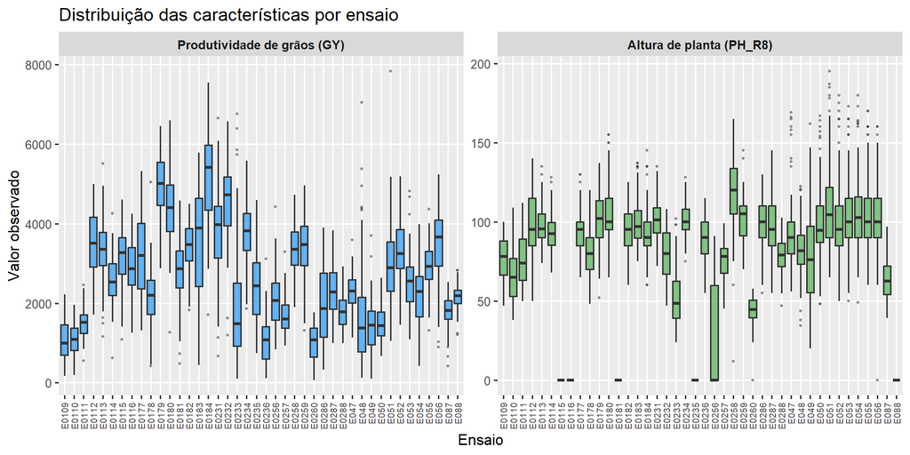

```r
p_box_env = ggplot(dat_long, aes(x = env, y = value, fill = trait)) +
  geom_boxplot(alpha = 0.7, outlier.size = 0.8, outlier.alpha = 0.5) +
  facet_wrap(~ trait, scales = "free_y", labeller = labeller(trait = c(GY = "Produtividade de grãos (GY)", PH_R8 = "Altura de planta (PH_R8)"))) +
  scale_fill_manual(values = c("GY" = "#2196F3", "PH_R8" = "#4CAF50"), guide = "none") +
  theme_gray(base_size = 12) +
  theme(
    axis.text.x = element_text(angle = 90, hjust = 1, vjust = 0.5, size = 7),
    strip.text = element_text(face = "bold"),
    panel.grid.minor = element_blank()) +
  labs(
    x = "Ensaio",
    y = "Valor observado",
    title = "Distribuição das características por ensaio"); p_box_env
```

Os boxplots por ensaio mostraram diferenças na distribuição das duas características entre os ambientes. Para produtividade de grãos, a variação entre ensaios foi bastante expressiva, tanto em relação às medianas quanto à amplitude dos valores observados. Esse comportamento indica que a produtividade foi fortemente afetada pelas condições ambientais específicas de cada ensaio. Alguns ambientes apresentaram maior dispersão e presença de valores extremos, o que pode refletir maior heterogeneidade experimental, diferenças de manejo ou maior sensibilidade dos genótipos ao ambiente. Para altura de planta, a variação entre ensaios também foi observada, porém de forma relativamente menos irregular do que para produtividade. Com base nesses resultados, fica evidente a necessidade da análise individual por ambiente, pois os padrões de distribuição não foram homogêneos entre os ensaios.

## 4.2 Boxplot por ano

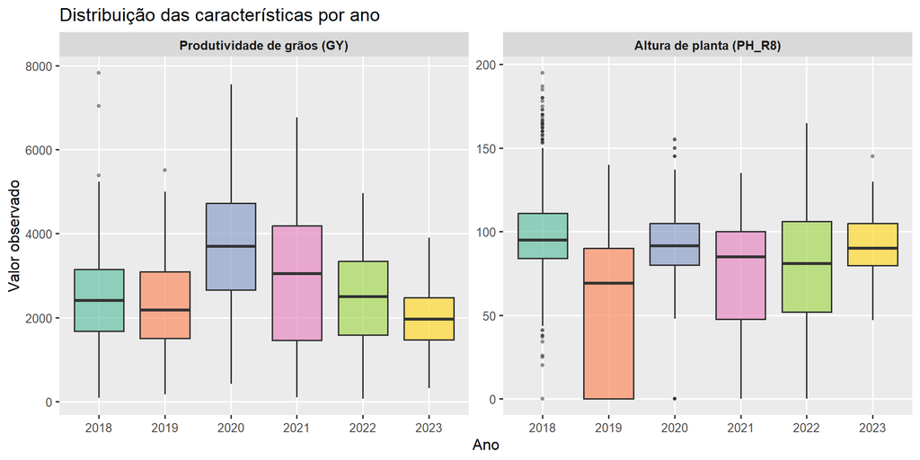

```r
p_box_year = ggplot(dat_long, aes(x = YEAR, y = value, fill = YEAR)) +
  geom_boxplot(alpha = 0.7, outlier.size = 1, outlier.alpha = 0.5) +
  facet_wrap(~ trait, scales = "free_y", labeller = labeller(trait = c(GY = "Produtividade de grãos (GY)", PH_R8 = "Altura de planta (PH_R8)"))) +
  scale_fill_brewer(palette = "Set2", guide = "none") +
  theme_gray(base_size = 12) +
  theme(
    strip.text = element_text(face = "bold"),
    panel.grid.minor = element_blank()) +
  labs(
    x = "Ano",
    y = "Valor observado",
    title = "Distribuição das características por ano"); p_box_year
```

A distribuição das características por ano indica que houve variação temporal no desempenho dos genótipos. Para produtividade de grãos, as diferenças entre anos foram mais evidentes, com alterações nas medianas e na amplitude dos valores observados. Esse resultado sugere que a produtividade foi influenciada por condições de cada ano agrícola (como disponibilidade hídrica, temperatura, manejo e outros fatores ambientais). Para altura de planta, a variação entre anos também ocorreu, mas de forma menos intensa do que para GY. Esse contraste entre as duas características indica que a produtividade apresenta maior sensibilidade às variações ambientais, enquanto a altura de planta tende a apresentar maior estabilidade relativa.

## 4.3 Médias observadas por ambiente

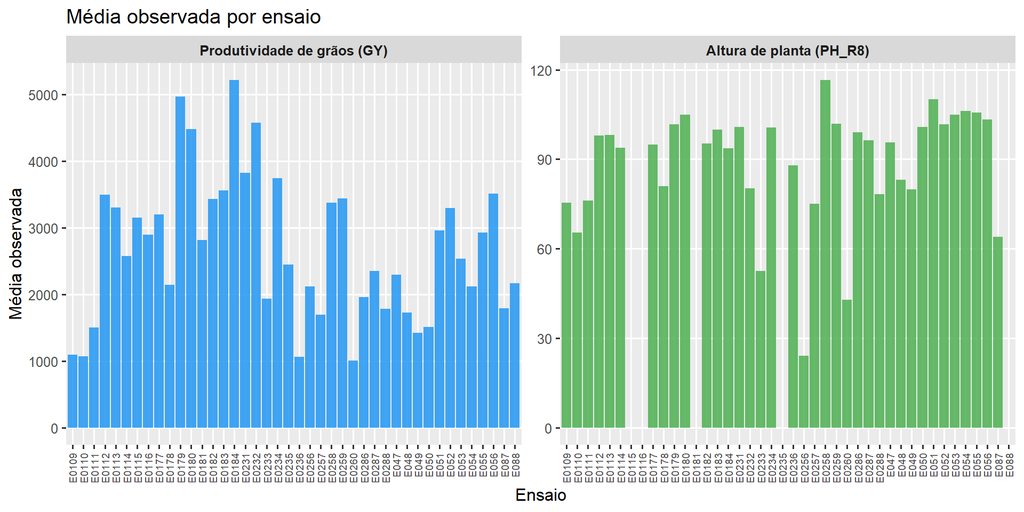

```r
# Médias observadas por ambiente
p_mean_env = trait_summary %>%
  ggplot(aes(x = env, y = mean, fill = trait)) +
  geom_col(alpha = 0.85) +
  facet_wrap(~ trait, scales = "free_y", labeller = labeller(trait = c(GY = "Produtividade de grãos (GY)", PH_R8 = "Altura de planta (PH_R8)"))) +
  scale_fill_manual(values = c("GY" = "#2196F3", "PH_R8" = "#4CAF50"), guide = "none") +
  theme_gray(base_size = 12) +
  theme(
    axis.text.x = element_text(angle = 90, hjust = 1, vjust = 0.5, size = 7),
    strip.text = element_text(face = "bold"),
    panel.grid.minor = element_blank()) +
  labs(
    x = "Ensaio",
    y = "Média observada",
    title = "Média observada por ensaio"); p_mean_env
```

As médias observadas por ambiente confirmam a existência de diferenças importantes entre os ensaios. Para produtividade de grãos, alguns ambientes apresentaram médias muito superiores às de outros, evidenciando que as condições ambientais tiveram grande impacto no desempenho produtivo. Para altura de planta, as médias também variaram entre ambientes, mas com menor contraste em relação à produtividade. A variação nas médias ambientais indica que os ambientes não podem ser considerados equivalentes quanto ao potencial de expressão das características avaliadas. Esse padrão sugere que, principalmente para GY, pode existir interação entre genótipos e ambientes, uma vez que o desempenho médio muda consideravelmente entre os ensaios.

# 5 Análise individual por ambiente (GY e PH_R8)

## 5.1 Análise para produtividade de grãos (GY)

### 5.1.1 Ajuste do modelo misto

```r
# fixed = GY ~ rep
# random = ~ gen
# data = subset(dat, env == "x"))

# Função que ajusta o modelo e todas as análise
ajustar_individual_completo = function(amb, trait, dados) {
  sub = dados %>% filter(env == amb) %>% drop_na(!!sym(trait))
  if(nrow(sub) == 0) return(NULL)

  # Modelo completo
  mod = asreml(
    fixed = as.formula(paste(trait, "~ rep")),
    random = ~ gen,
    data = sub,
    na.action = na.method(x = "include", y = "include"))

  # Componentes de variância
  vc = summary(mod)$varcomp
  Vg = vc["gen", "component"]
  Ve = vc["units!R", "component"]

  # Média geral e número harmônico de repetições
  mu = mean(sub[[trait]], na.rm = TRUE)
  reps = sub %>% count(gen) %>% pull(n)
  r_harm = length(reps) / sum(1/reps)

  # Herdabilidade e CVe
  H2 = Vg / (Vg + Ve / r_harm)
  CVe = sqrt(Ve) / mu * 100

  # Teste LRT (modelo reduzido sem gen)
  mod_red = asreml(
    fixed = as.formula(paste(trait, "~ rep")),
    data = sub,
    na.action = na.method(x = "include", y = "include"))

  LRT = -2 * (mod_red$loglik - mod$loglik)
  p_val = 0.5 * pchisq(LRT, df = 1, lower.tail = FALSE)

  # BLUPs e confiabilidade
  pred = predict(mod, classify = "gen")$pvals %>%
    as_tibble() %>%
    rename(BLUP = predicted.value, SE = std.error) %>%
    mutate(
      PEV = SE^2,
      Confiabilidade = 1 - PEV / Vg,
      Ambiente = amb,
      Genotipo = gen) %>%
    select(Ambiente, Genotipo, BLUP, SE, PEV, Confiabilidade)

  list(
    Ambiente = amb,
    componentes = tibble(Ambiente = amb, sigma2_g = Vg, sigma2_e = Ve),
    herdabilidade = tibble(Ambiente = amb, H2 = H2, CVe = CVe),
    lrt = tibble(Ambiente = amb, LRT = LRT, p_valor = p_val),
    blups = pred)
}

# Executar para todos os ambientes
resultados_GY = map(ambientes, ~ ajustar_individual_completo(.x, "GY", dat_zim))
names(resultados_GY) = ambientes

# Remover ambientes que retornaram NULL (se tiver)
resultados_GY = compact(resultados_GY)
```

### 5.1.2 Componentes de variância (GY)

```r
vc_GY_ind = map_dfr(resultados_GY, ~ .x$componentes)

DT::datatable(
  vc_GY_ind,
  caption = "Estimativas dos componentes de variância.",
  options = list(pageLength = 10, scrollX = TRUE),
  rownames = FALSE) %>%
  DT::formatRound(columns = c("sigma2_g", "sigma2_e"), digits = 3, dec.mark = ".", mark = "")
```

| Ambiente | sigma2_g | sigma2_e |
| --- | --- | --- |
| E047 | 61983.49608358301 | 89155.05778914528 |
| E048 | 357381.7596597702 | 1031922.67719471 |
| E049 | 200581.816565315 | 234757.2415187606 |
| E050 | 43713.4691200539 | 150712.6572051045 |
| E051 | 619789.7743211508 | 361342.1945217205 |
| E052 | 330922.1419481806 | 172315.2346946441 |
| E053 | 165411.8383509806 | 324929.2134701121 |
| E054 | 554166.1313990771 | 113706.2055593121 |
| E055 | 184716.1169600008 | 168639.1435770378 |
| E056 | 649899.6569433997 | 311598.1297190136 |

[output cut: 32 more lines]

As estimativas dos componentes de variância para produtividade de grãos mostraram que tanto a variância genética quanto a variância residual variaram consideravelmente entre os ambientes. Em alguns ensaios, a variância residual foi elevada, como observado em E048, indicando menor precisão experimental e maior influência de fatores não controlados sobre a produtividade. Por outro lado, em ambientes como E054, E052 e E056, a variância genética apresentou maior contribuição relativa, sugerindo melhor capacidade de discriminação entre os genótipos. Essa diferença entre ambientes mostra que a produtividade de grãos não apresentou o mesmo nível de controle genético em todos os ensaios. Assim, os ambientes com maior variância genética e menor variância residual são mais informativos para a seleção de genótipos superiores.

### 5.1.3 Herdabilidade e CVe (GY)

```r
herd_cve_GY_ind = map_dfr(resultados_GY, ~ .x$herdabilidade)

DT::datatable(
  herd_cve_GY_ind,
  caption = "Estimativas de Herdabilidade e CVe.",
  options = list(pageLength = 10, scrollX = TRUE),
  rownames = FALSE) %>%
  DT::formatRound(columns = c("H2", "CVe"), digits = 4, dec.mark = ".", mark = "")
```

| Ambiente | H2 | CVe |
| --- | --- | --- |
| E047 | 0.6759241713861468 | 13.00242702691523 |
| E048 | 0.4973619423991619 | 58.75943505782561 |
| E049 | 0.7029196277193547 | 34.1179125340298 |
| E050 | 0.4652793382340347 | 25.65976719290295 |
| E051 | 0.8372853962900505 | 20.2959192338341 |
| E052 | 0.8521002943133628 | 12.59731811915846 |
| E053 | 0.6043069043472806 | 22.48750028425756 |
| E054 | 0.9359836104608122 | 15.89407604434896 |
| E055 | 0.7666822615633107 | 14.04183255101337 |
| E056 | 0.8622038078749872 | 15.88749312680459 |

[output cut: 32 more lines]

As estimativas de herdabilidade para produtividade de grãos variaram entre os ambientes, indicando que a proporção da variação atribuída às diferenças genéticas não foi constante ao longo dos ensaios. Ambientes como E054, E056, E052 e E051 apresentaram valores elevados de herdabilidade, o que sugere maior eficiência na seleção de genótipos superiores nesses locais. Em contraste, ambientes como E048 e E050 apresentaram menores valores de herdabilidade, indicando menor precisão para discriminar diferenças genéticas entre os materiais avaliados. O coeficiente de variação experimental também variou entre os ambientes, sendo especialmente elevado em E048, o que indica maior variação residual em relação à média do ensaio.

### 5.1.4 Teste de hipótese

$$H_0: \sigma_g^2=0, \quad H_1:\sigma_g^2\neq 0$$
O teste da razão de verossimilhança foi utilizado para avaliar se a inclusão do efeito aleatório de genótipo melhorou significativamente o ajuste do modelo. A hipótese nula considera ausência de variância genética entre os genótipos, ou seja, assume que os materiais avaliados não diferem geneticamente para produtividade dentro do ambiente. A hipótese alternativa considera a existência de variabilidade genética significativa, justificando a inclusão do efeito de genótipo no modelo e a predição dos valores genotípicos por meio dos BLUPs. Dessa forma, valores significativos do LRT indicam que existem diferenças genéticas detectáveis entre os genótipos avaliados.

```r
lrt_GY_ind = map_dfr(resultados_GY, ~ .x$lrt)

DT::datatable(
  lrt_GY_ind,
  caption = "Estimativas de LRT e p_value.",
  options = list(pageLength = 10, scrollX = TRUE),
  rownames = FALSE) %>%
  DT::formatRound(columns = c("LRT", "p_valor"), digits = 4, dec.mark = ".", mark = "")
```

| Ambiente | LRT | p_valor |
| --- | --- | --- |
| E047 | 13.24377784229819 | 0.0001367430817007531 |
| E048 | 4.593238862317094 | 0.01604915198680896 |
| E049 | 14.96751812371895 | 5.468891642303209e-05 |
| E050 | 4.00260210808915 | 0.02271503790902631 |
| E051 | 34.24573550641321 | 2.428693410269849e-09 |
| E052 | 37.81567571807318 | 3.88772332524414e-10 |
| E053 | 8.913589009742509 | 0.001415282126664823 |
| E054 | 74.32181056927129 | 3.318310463370768e-18 |
| E055 | 22.14974330700602 | 1.260948432368075e-06 |
| E056 | 40.55229355556321 | 9.571185504788992e-11 |

[output cut: 32 more lines]

Os resultados do teste LRT para produtividade de grãos indicaram significância estatística nos ambientes apresentados, com valores de p inferiores a 5%. Esse resultado permite rejeitar a hipótese nula de ausência de variância genética e confirma que há diferenças genotípicas detectáveis para produtividade dentro dos ambientes avaliados. A significância do efeito genotípico justifica o uso dos BLUPs para identificar candidatos superiores em cada ensaio. No entanto, a interpretação desses resultados deve ser feita em conjunto com a herdabilidade, o CVe e a confiabilidade das predições, pois nem todos os ambientes apresentaram a mesma precisão experimental.

### 5.1.5 BLUPs e confiabilidade (GY)

```r
blups_GY_ind = map_dfr(resultados_GY, ~ .x$blups)

DT::datatable(
  blups_GY_ind,
  caption = "BLUPs dos efeitos genotípicos e confiabilidade",
  options = list(pageLength = 10, scrollX = TRUE),
  rownames = FALSE) %>%
  DT::formatRound(columns = c("BLUP", "SE", "PEV", "Confiabilidade"), digits = 4, dec.mark = ".", mark = "")
```

| Ambiente | Genotipo | BLUP | SE | PEV | Confiabilidade |
| --- | --- | --- | --- | --- | --- |
| E047 | G018 | 2163.186122460314 | 142.8568007678799 | 20408.06552563374 | 0.6707500090328233 |
| E047 | G034 | 2380.486731392994 | 142.8568007678799 | 20408.06552563374 | 0.6707500090328233 |
| E047 | G056 | 2074.669345993294 | 142.8568007678799 | 20408.06552563374 | 0.6707500090328233 |
| E047 | G065 | 2017.87143783138 | 142.8568007678799 | 20408.06552563374 | 0.6707500090328233 |
| E047 | G070 | 2582.23207205046 | 142.8568007678799 | 20408.06552563374 | 0.6707500090328233 |
| E047 | G074 | 2325.092492427989 | 142.8568007678799 | 20408.06552563374 | 0.6707500090328233 |
| E047 | G081 | 2348.930084889135 | 142.8568007678799 | 20408.06552563374 | 0.6707500090328233 |
| E047 | G082 | 2196.822362332947 | 142.8568007678799 | 20408.06552563374 | 0.6707500090328233 |
| E047 | G084 | 2308.789201402577 | 142.8568007678799 | 20408.06552563374 | 0.6707500090328233 |
| E047 | G092 | 2715.231418267992 | 142.8568007678799 | 20408.06552563374 | 0.6707500090328233 |

[output cut: 1274 more lines]

Os BLUPs representam os valores genotípicos preditos para produtividade de grãos em cada ambiente, após o ajuste para o efeito de blocos. Esses valores permitem comparar os genótipos de forma mais adequada do que a simples média observada, pois consideram a estrutura do modelo misto e a variação associada aos efeitos aleatórios.

### 5.1.6 Candidatos à seleção (GY)

```r
# Top ambientes para seleção
top_GY_ind = blups_GY_ind %>%
  group_by(Ambiente) %>%
  slice_max(BLUP, n = 5) %>%
  select(Ambiente, Genotipo, BLUP, Confiabilidade)

# Top 5 ambientes
top5_geral_GY = blups_GY_ind %>%
  group_by(Genotipo) %>%
  summarise(BLUP_medio = mean(BLUP)) %>%
  slice_max(BLUP_medio, n = 5) %>%
  arrange(desc(BLUP_medio))

DT::datatable(
  top_GY_ind,
  caption = "Top 5 genótipos por ambiente",
  options = list(pageLength = 10, scrollX = TRUE),
  rownames = FALSE) %>%
  DT::formatRound(columns = c("BLUP", "Confiabilidade"), digits = 4, dec.mark = ".", mark = "")
```

| Ambiente | Genotipo | BLUP | Confiabilidade |
| --- | --- | --- | --- |
| E0109 | G072 | 1385.366869085402 | 0.4154544322440252 |
| E0109 | G145 | 1307.140269811842 | 0.4154544322440252 |
| E0109 | G210 | 1295.741833827017 | 0.4154544322440252 |
| E0109 | G233 | 1281.451322935969 | 0.4154544322440252 |
| E0109 | G219 | 1265.286454637344 | 0.4154544322440252 |
| E0110 | G146 | 1104.635911875921 | -0.1741740824018181 |
| E0110 | G092 | 1100.318754003304 | -0.1741740824018181 |
| E0110 | G210 | 1100.270558174477 | -0.1741740824018181 |
| E0110 | G074 | 1094.672909753772 | -0.1741740824018181 |
| E0110 | G144 | 1088.616080525542 | -0.1741740824018181 |

[output cut: 200 more lines]

```r
DT::datatable(
  top5_geral_GY,
  caption = "Top 5 genótipos (média dos BLUPs)",
  options = list(pageLength = 10, scrollX = TRUE),
  rownames = FALSE) %>%
  DT::formatRound(columns = c("BLUP_medio"), digits = 4, dec.mark = ".", mark = "")
```

| Genotipo | BLUP_medio |
| --- | --- |
| G141 | 4000.33445478835 |
| G149 | 3978.052432963099 |
| G137 | 3645.56346296729 |
| G115 | 3627.433423107354 |
| G002 | 3550.29693344655 |

Considerando a média dos BLUPs ao longo dos ambientes, os genótipos G141, G149, G137, G115 e G002 apresentaram os maiores valores para produtividade de grãos. Esses genótipos podem ser considerados candidatos promissores para seleção com base no desempenho produtivo médio. O genótipo G141 apresentou o maior BLUP médio, seguido por G149, indicando destaque produtivo em relação aos demais materiais avaliados. Entretanto, a seleção baseada apenas no BLUP médio pode não representar completamente o comportamento dos genótipos em todos os ambientes. Como a produtividade apresentou forte influência ambiental, é necessário avaliar também a estabilidade e a resposta dos genótipos ao longo dos diferentes ensaios.

### 5.1.7 Análise gráfica (GY)

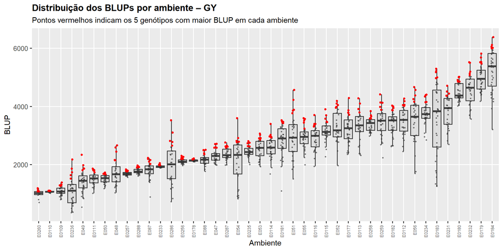

```r
# Boxplot com destaque + fill por ambiente
blups_GY_ind = blups_GY_ind %>%
  group_by(Ambiente) %>%
  mutate(top5 = ifelse(rank(-BLUP) <= 5, "Top 5", "Demais")) %>%
  ungroup()

# Ordenar os ambientes pela mediana dos BLUPs
ordem_amb_GY = blups_GY_ind %>%
  group_by(Ambiente) %>%
  summarise(mediana_BLUP = median(BLUP), .groups = "drop") %>%
  arrange(mediana_BLUP) %>%
  pull(Ambiente)

blups_GY_ind$Ambiente = factor(blups_GY_ind$Ambiente, levels = ordem_amb_GY)

ggplot(blups_GY_ind, aes(x = Ambiente, y = BLUP)) +
  geom_boxplot(fill = "gray85", color = "gray25", alpha = 0.8,
    outlier.shape = NA, linewidth = 0.7) +
  geom_jitter(data = blups_GY_ind %>% filter(top5 == "Demais"),
    color = "gray20", width = 0.12, alpha = 0.45, size = 0.55) +
  geom_jitter(data = blups_GY_ind %>% filter(top5 == "Top 5"),
              color = "red", width = 0.12, alpha = 0.95, size = 1.0) +
  theme_gray(base_size = 12) +
  theme(
    axis.text.x = element_text(angle = 90, hjust = 1, vjust = 0.5, size = 6),
    axis.title = element_text(size = 11),
    plot.title = element_text(face = "bold", size = 13),
    plot.subtitle = element_text(size = 11),
    panel.grid.minor = element_blank(),
    legend.position = "none") +
  labs(
    title = "Distribuição dos BLUPs por ambiente – GY",
    subtitle = "Pontos vermelhos indicam os 5 genótipos com maior BLUP em cada ambiente",
    x = "Ambiente",
    y = "BLUP")
```

A distribuição dos BLUPs por ambiente para produtividade de grãos mostrou ampla variação no desempenho genotípico predito entre os ensaios. Os ambientes foram ordenados de acordo com a mediana dos BLUPs, permitindo visualizar um gradiente de ambientes menos favoráveis para ambientes mais favoráveis à expressão da produtividade. Observa-se que alguns ambientes apresentaram menor dispersão dos BLUPs, indicando maior homogeneidade entre os genótipos, enquanto outros apresentaram maior amplitude, sugerindo maior capacidade de discriminação genotípica. Os pontos destacados em vermelho representam os cinco genótipos com maior BLUP em cada ambiente, evidenciando que os materiais superiores variam conforme o ensaio. Esse padrão reforça que a produtividade de grãos é fortemente influenciada pelo ambiente e que a seleção de genótipos superiores deve considerar o desempenho específico em cada local.

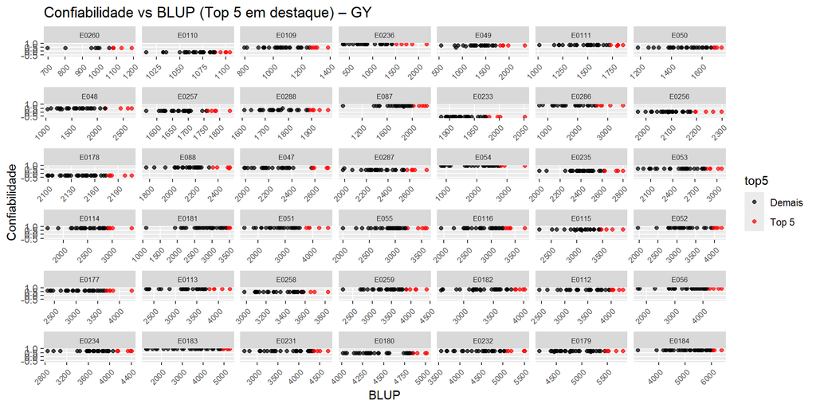

```r
# Confiabilidade vs. BLUP com destaque
ggplot(blups_GY_ind, aes(x = BLUP, y = Confiabilidade, color = top5)) +
  geom_point(alpha = 0.7, size = 1.5) +
  scale_color_manual(values = c("Top 5" = "red", "Demais" = "black")) +
  facet_wrap(~ Ambiente, scales = "free_x") +
  theme_gray(base_size = 11) +
  theme(panel.grid.minor = element_blank(),
        strip.text = element_text(size = 6),
        axis.text.x = element_text(angle = 45, hjust = 1, size = 7)) +
  labs(title = "Confiabilidade vs BLUP (Top 5 em destaque) – GY")
```

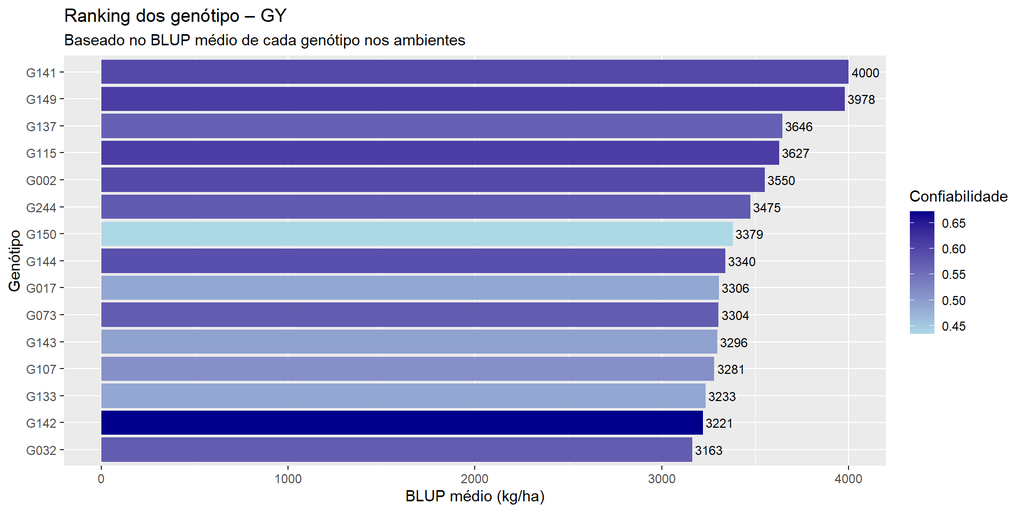

```r
# Gráfico de ranking
# Calcular médias por genótipo
rank_gy = blups_GY_ind %>%
  group_by(Genotipo) %>%
  summarise(
    BLUP_medio = mean(BLUP),
    Conf_media = mean(Confiabilidade)) %>%
  slice_max(BLUP_medio, n = 15) %>%
  mutate(Genotipo = fct_reorder(Genotipo, BLUP_medio))

ggplot(rank_gy, aes(x = Genotipo, y = BLUP_medio, fill = Conf_media)) +
  geom_col() +
  geom_text(aes(label = round(BLUP_medio, 0)), hjust = -0.1, size = 3.2) +
  scale_fill_gradient(low = "lightblue", high = "darkblue", name = "Confiabilidade") +
  coord_flip() +
  theme_gray() +
  labs(
    title = "Ranking dos genótipo – GY",
    subtitle = "Baseado no BLUP médio de cada genótipo nos ambientes",
    x = "Genótipo",
    y = "BLUP médio (kg/ha)")
```

O ranking dos genótipos para produtividade de grãos, baseado no BLUP médio ao longo dos ambientes, permitiu identificar os materiais com melhor desempenho geral. Os genótipos G141 e G149 apresentaram os maiores valores médios de BLUP, seguidos por G137, G115 e G002, indicando maior potencial produtivo médio entre os genótipos avaliados.

**Grupo 1**

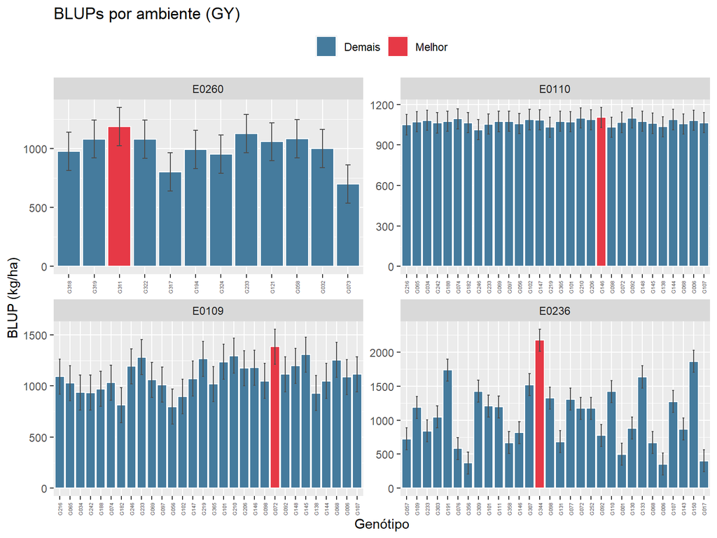

**Grupo 2**

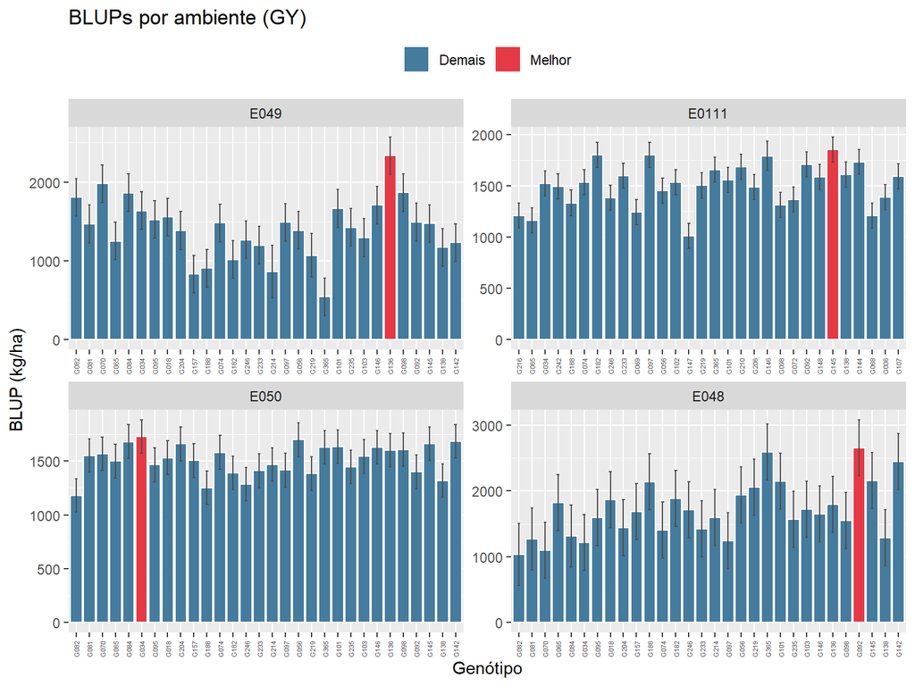

**Grupo 3**

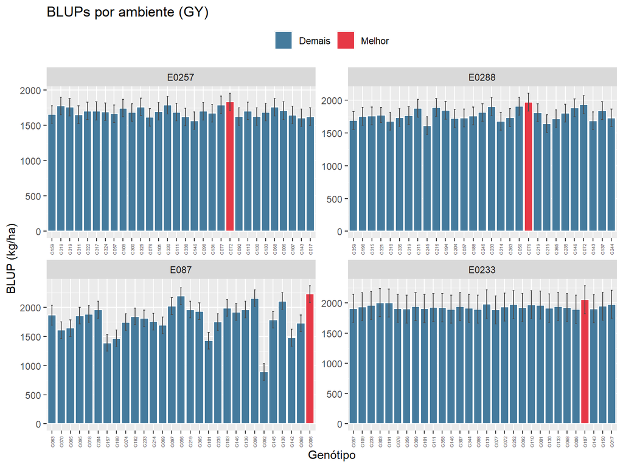

**Grupo 4**

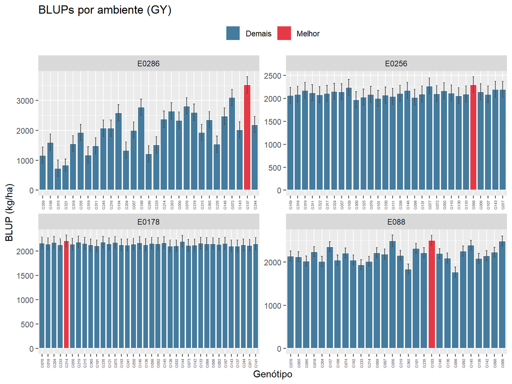

**Grupo 5**

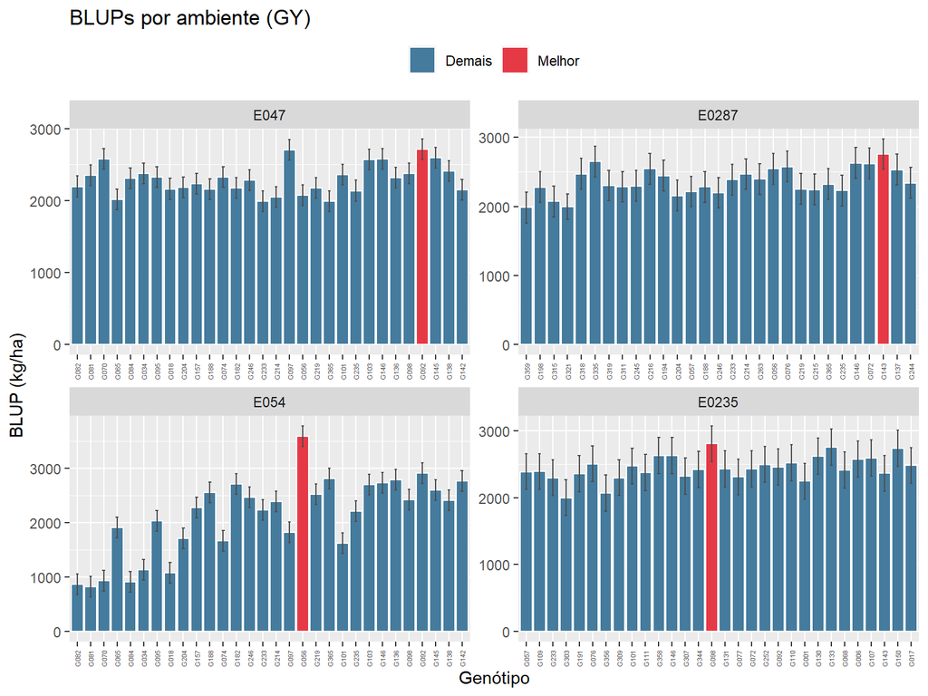

**Grupo 6**

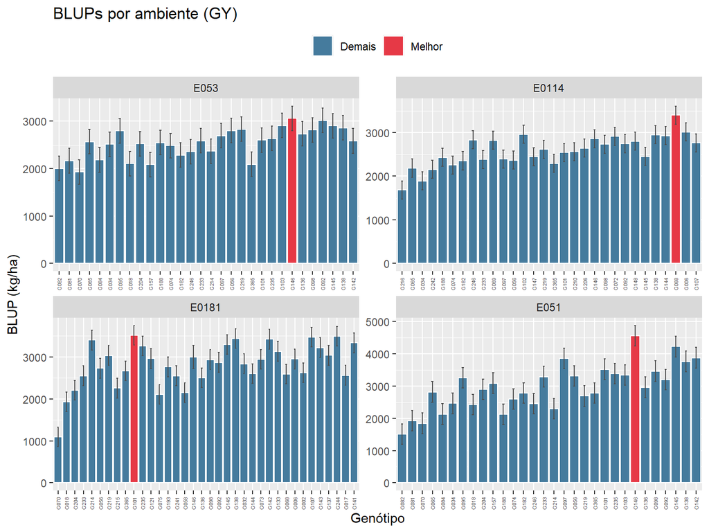

**Grupo 7**

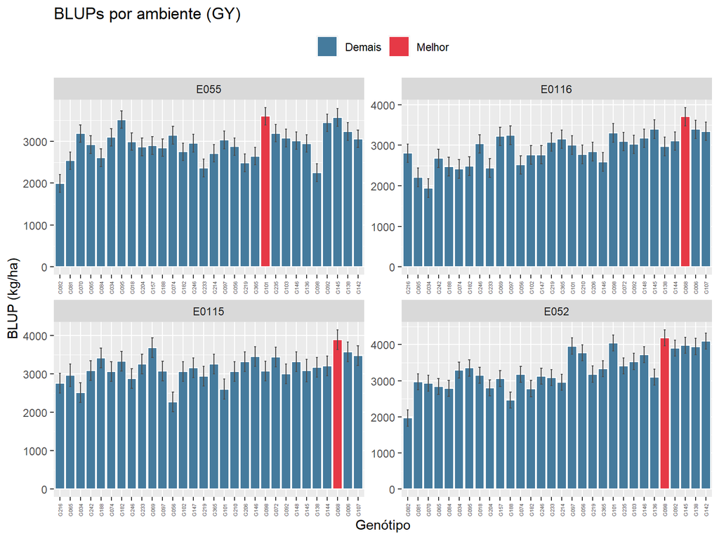

**Grupo 8**

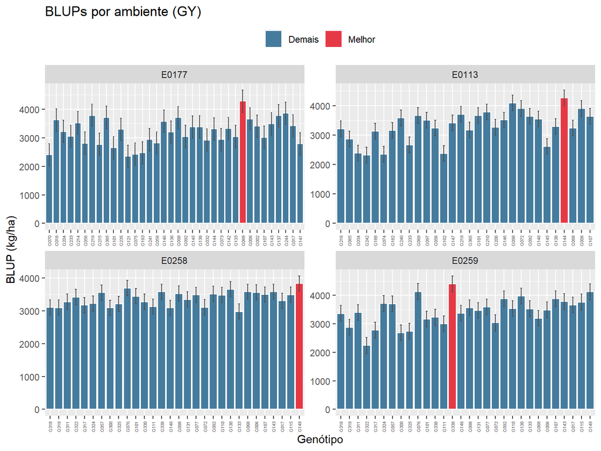

**Grupo 9**

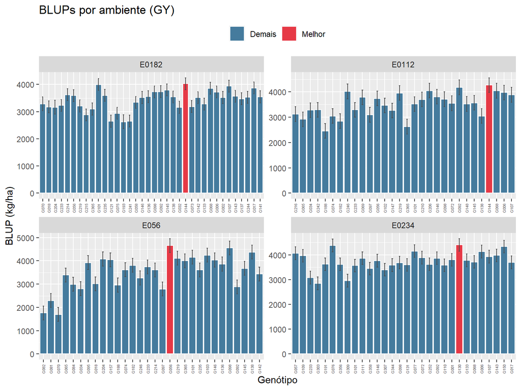

**Grupo 10**

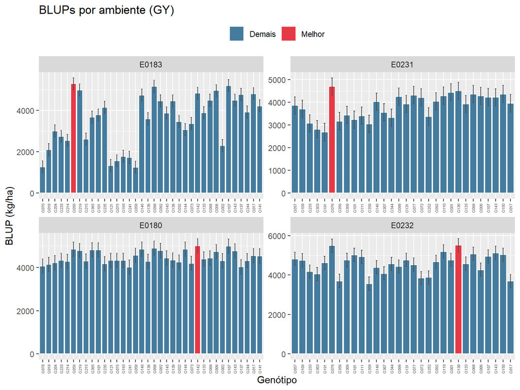

**Grupo 11**

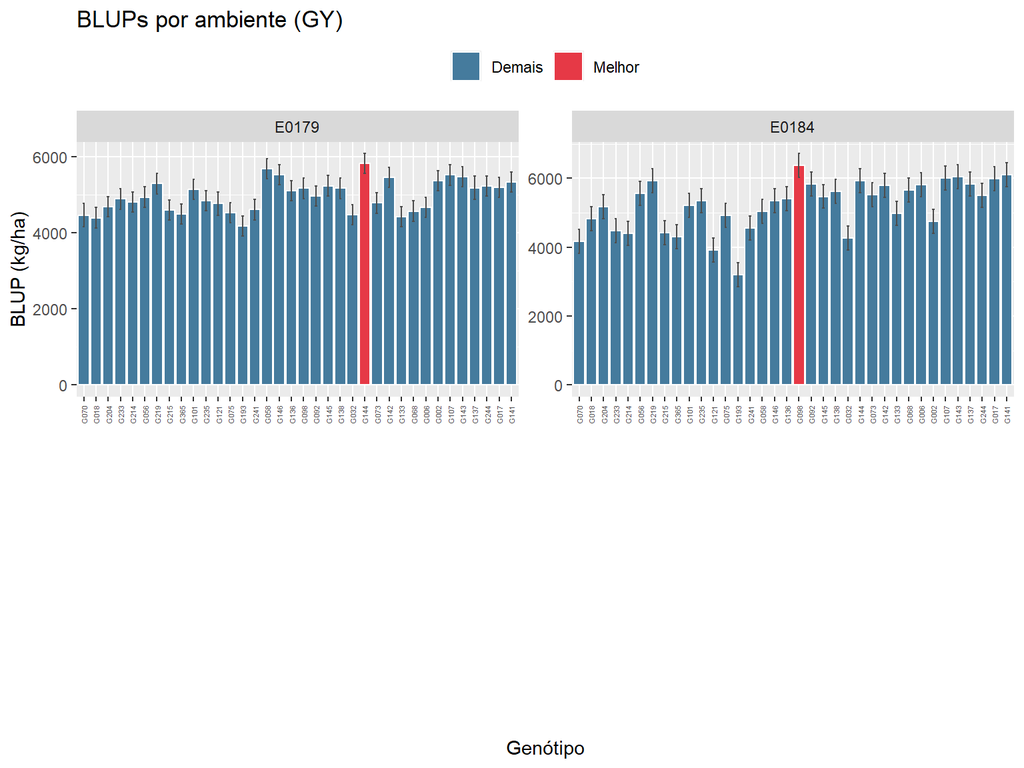

O gráfico de BLUPs por ambiente para produtividade de grãos permite observar, de forma mais detalhada, o desempenho dos genótipos dentro de grupos de ambientes. Em cada painel, os genótipos são comparados dentro de um ambiente específico, e o material com maior BLUP é destacado em vermelho. Com base no gráfico, é possivel a identificação dos genótipos superiores em cada ensaio e mostra que o melhor genótipo nem sempre é o mesmo entre os ambientes.

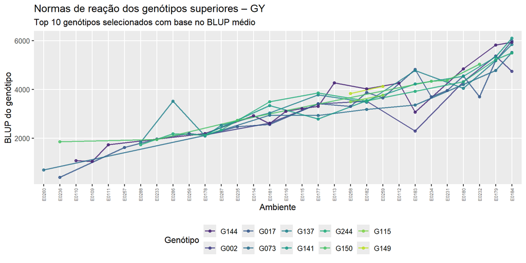

```r
# Normas de reação dos genótipos superiores
# Selecionar os 10 melhores genótipos
top10_gen = rank_gy %>%
  slice_max(BLUP_medio, n = 10) %>%
  pull(Genotipo)

# Criar índice ambiental para ordenar os ambientes
indice_amb = blups_GY_ind %>%
  group_by(Ambiente) %>%
  summarise(indice = mean(BLUP))

# Dados dos Top 10
dados_norma = blups_GY_ind %>%
  filter(Genotipo %in% top10_gen) %>%
  left_join(indice_amb, by = "Ambiente")

# Ordenar ambientes do menos favorável para o mais favorável
ordem_amb = indice_amb %>%
  arrange(indice) %>%
  pull(Ambiente)

dados_norma$Ambiente = factor(dados_norma$Ambiente, levels = ordem_amb)

ggplot(dados_norma, aes(x = Ambiente, y = BLUP, group = Genotipo, color = Genotipo)) +
  geom_line(linewidth = 0.8, alpha = 0.8) +
  geom_point(size = 1.6, alpha = 0.8) +
  scale_color_viridis_d(option = "D", begin = 0.1, end = 0.9) +
  theme_gray(base_size = 12) +
  theme(
    axis.text.x = element_text(angle = 90, hjust = 1, vjust = 0.5, size = 6),
    panel.grid.minor = element_blank(),
    legend.position = "bottom") +
  labs(
    title = "Normas de reação dos genótipos superiores – GY",
    subtitle = "Top 10 genótipos selecionados com base no BLUP médio",
    x = "Ambiente",
    y = "BLUP do genótipo",
    color = "Genótipo")
```

As normas de reação dos genótipos superiores para produtividade de grãos mostraram que os dez melhores genótipos, selecionados com base no BLUP médio, apresentaram respostas distintas ao longo dos ambientes. Os ambientes foram organizados de acordo com o índice ambiental, permitindo visualizar o comportamento dos genótipos desde condições menos favoráveis até condições mais favoráveis. A presença de cruzamentos entre as linhas indica alteração na classificação dos genótipos entre ambientes, evidenciando interação GxE. Alguns materiais apresentaram maior resposta em ambientes favoráveis, enquanto outros mantiveram desempenho relativamente mais estável. Dessa forma, a escolha de genótipos superiores para produtividade deve considerar não apenas o BLUP médio, mas também a estabilidade e a adaptabilidade dos materiais.

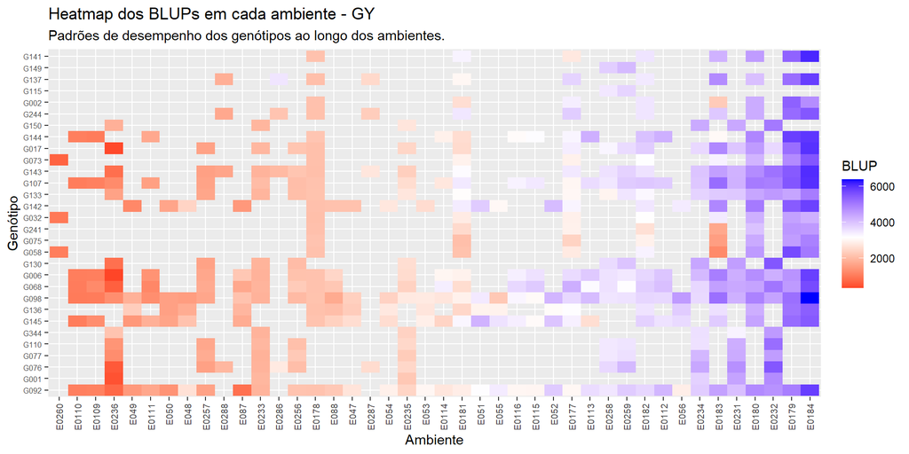

```r
# Top 30 genótipos com maior BLUP médio
top30 = blups_GY_ind %>%
  group_by(Genotipo) %>%
  summarise(BLUP_medio = mean(BLUP)) %>%
  slice_max(BLUP_medio, n = 30) %>%
  pull(Genotipo)

heat_data = blups_GY_ind %>%
  filter(Genotipo %in% top30) %>%
  mutate(Genotipo = fct_reorder(Genotipo, BLUP, .fun = mean))

ggplot(heat_data, aes(x = Ambiente, y = Genotipo, fill = BLUP)) +
  geom_tile() +
  scale_fill_gradient2(low = "red", mid = "white", high = "blue", midpoint = mean(heat_data$BLUP)) +
  theme_gray() +
  labs(
    title = "Heatmap dos BLUPs em cada ambiente - GY",
    subtitle = "Padrões de desempenho dos genótipos ao longo dos ambientes.",
    x = "Ambiente",
    y = "Genótipo",
    fill = "BLUP") +
  theme(
    axis.text.y = element_text(size = 6),
    axis.text.x = element_text(angle = 90, hjust = 1, vjust = 0.5, size = 7))
```

O heatmap dos BLUPs para produtividade de grãos permitiu visualizar os padrões de desempenho dos genótipos ao longo dos ambientes. As cores indicam diferenças na magnitude dos BLUPs, com tons mais intensos representando valores mais altos ou mais baixos em relação ao ponto médio da escala. Observa-se que alguns genótipos apresentaram desempenho superior em determinados ambientes, mas não mantiveram necessariamente o mesmo padrão em todos os ensaios. Essa variação confirma que a resposta produtiva dos genótipos depende das condições ambientais.

## 5.2 Análise para altura de planta (PH_R8)

### 5.2.1 Ajuste do modelo misto (análogo ao modelo GY)

```r
# Executar para todos os ambientes
resultados_PH = map(ambientes, ~ ajustar_individual_completo(.x, "PH_R8", dat_zim))
names(resultados_PH) = ambientes
resultados_PH = compact(resultados_PH)
```

### 5.2.2 Componentes de variância (PH_R8)

```r
vc_PH_ind = map_dfr(resultados_PH, ~ .x$componentes)

DT::datatable(
  vc_PH_ind,
  caption = "Estimativas dos componentes de variância",
  options = list(pageLength = 10, scrollX = TRUE),
  rownames = FALSE) %>%
  DT::formatRound(columns = c("sigma2_g", "sigma2_e"), digits = 3, dec.mark = ".", mark = "")
```

| Ambiente | sigma2_g | sigma2_e |
| --- | --- | --- |
| E047 | 562.5747366637225 | 9.619258738292018 |
| E048 | 242.9558821752013 | 87.89849395782839 |
| E049 | 845.3728266099247 | 124.2484039042704 |
| E050 | 493.612761221747 | 83.96541479568316 |
| E051 | 587.3138151106559 | 245.3151886172004 |
| E052 | 623.1938655128374 | 88.59578299232099 |
| E053 | 484.7229989860626 | 123.180657167969 |
| E054 | 548.5323991905328 | 74.07351959355194 |
| E055 | 539.073580815535 | 67.54823100103616 |
| E056 | 353.5129974874238 | 232.4261348760186 |

[output cut: 32 more lines]

As estimativas dos componentes de variância para PH_R8 indicaram presença expressiva de variabilidade genética entre os genótipos. Em vários ambientes, a variância genética foi superior à variância residual, sugerindo boa capacidade de discriminação genotípica para altura de planta. Esse padrão foi diferente do observado para produtividade de grãos, em que a variância residual apresentou maior peso em alguns ambientes. Para PH_R8, a menor contribuição relativa do erro experimental indica maior precisão na avaliação da característica. Portanto, a altura de planta apresentou maior estabilidade e maior controle genético relativo em comparação com a produtividade.

### 5.2.3 Herdabilidade e CVe (PH_R8)

```r
herd_cve_PH_ind = map_dfr(resultados_PH, ~ .x$herdabilidade)

DT::datatable(
  herd_cve_PH_ind,
  caption = "Estimativas de herdabilidade e CVe",
  options = list(pageLength = 10, scrollX = TRUE),
  rownames = FALSE) %>%
  DT::formatRound(columns = c("H2", "CVe"), digits = 4, dec.mark = ".", mark = "")
```

| Ambiente | H2 | CVe |
| --- | --- | --- |
| E047 | 0.9943327565012564 | 3.244239524444376 |
| E048 | 0.8923822994109397 | 11.28118843457127 |
| E049 | 0.9532965153551012 | 13.95466564043161 |
| E050 | 0.9463412472259185 | 9.086533689151144 |
| E051 | 0.8777858374120523 | 14.23867357949719 |
| E052 | 0.9547559971234332 | 9.261265949189143 |
| E053 | 0.9219065621590348 | 10.58360919145462 |
| E054 | 0.9569257539515118 | 8.11092953004597 |
| E055 | 0.9599065319544624 | 7.782110231786142 |
| E056 | 0.8202378935350768 | 14.76485044771519 |

[output cut: 32 more lines]

As estimativas de herdabilidade para PH_R8 foram elevadas nos ambientes avaliados. Em muitos ensaios, os valores foram superiores a 0,90, indicando que grande parte da variação observada foi atribuída às diferenças genéticas entre os genótipos. Além disso, os valores de CVe foram relativamente baixos em comparação com os observados para produtividade de grãos, evidenciando maior precisão experimental na mensuração da altura de planta. Ambientes como E047, E054 e E055 apresentaram alta herdabilidade associada a baixos valores de CVe, indicando alta confiabilidade para seleção. Mesmo os ambientes com valores relativamente menores de herdabilidade para PH_R8 ainda apresentaram estimativas consideradas altas, reforçando a maior estabilidade dessa característica.

### 5.2.4 Teste de hipótese (análogo ao modelo GY)

```r
lrt_PH_ind = map_dfr(resultados_PH, ~ .x$lrt)

DT::datatable(
  lrt_PH_ind,
  caption = "Teste LRT",
  options = list(pageLength = 10, scrollX = TRUE),
  rownames = FALSE) %>%
  DT::formatRound(columns = c("LRT", "p_valor"), digits = 4, dec.mark = ".", mark = "")
```

| Ambiente | LRT | p_valor |
| --- | --- | --- |
| E047 | 205.4383771319562 | 6.793657328631603e-47 |
| E048 | 50.6721880087922 | 5.457771786338928e-13 |
| E049 | 89.89801573987734 | 1.253791917269844e-21 |
| E050 | 82.94596748305685 | 4.216360361840206e-20 |
| E051 | 45.36045709046812 | 8.19552550270389e-12 |
| E052 | 91.50687140656066 | 5.560267644859285e-22 |
| E053 | 64.93807232974586 | 3.864462588827943e-16 |
| E054 | 94.01037212155154 | 1.569374019430957e-22 |
| E055 | 97.69082618294237 | 2.445415204574161e-23 |
| E056 | 30.67647629967769 | 1.524192157044485e-08 |

[output cut: 32 more lines]

O teste LRT para PH_R8 indicou significância estatística para o efeito genotípico nos ambientes apresentados. Os valores de p próximos de zero permitem rejeitar a hipótese nula de ausência de variância genética, confirmando que existem diferenças genéticas detectáveis entre os genótipos para altura de planta. A significância do componente genético, associada às altas estimativas de herdabilidade, demonstra que PH_R8 é uma característica com boa resposta potencial à seleção.

### 5.2.5 BLUPs e confiabilidade (PH_R8)

```r
blups_PH_ind = map_dfr(resultados_PH, ~ .x$blups)

DT::datatable(
  blups_PH_ind,
  caption = "BLUPs e confiabilidade",
  options = list(pageLength = 10, scrollX = TRUE),
  rownames = FALSE) %>%
  DT::formatRound(columns = c("BLUP", "SE", "PEV", "Confiabilidade"), digits = 4, dec.mark = ".", mark = "")
```

| Ambiente | Genotipo | BLUP | SE | PEV | Confiabilidade |
| --- | --- | --- | --- | --- | --- |
| E047 | G018 | 72.46519103973655 | 1.785335515844296 | 3.187422904135019 | 0.994334223177106 |
| E047 | G034 | 89.70029227087836 | 1.785335515844296 | 3.187422904135019 | 0.994334223177106 |
| E047 | G056 | 90.0317365253234 | 1.785335515844296 | 3.187422904135019 | 0.994334223177106 |
| E047 | G065 | 99.31217564978438 | 1.785335515844296 | 3.187422904135019 | 0.994334223177106 |
| E047 | G070 | 91.35751354310354 | 1.785335515844296 | 3.187422904135019 | 0.994334223177106 |
| E047 | G074 | 88.70595950754326 | 1.785335515844296 | 3.187422904135019 | 0.994334223177106 |
| E047 | G081 | 157.3149201776655 | 1.785335515844296 | 3.187422904135019 | 0.994334223177106 |
| E047 | G082 | 166.2639150476814 | 1.785335515844296 | 3.187422904135019 | 0.994334223177106 |
| E047 | G084 | 137.4282649109634 | 1.785335515844296 | 3.187422904135019 | 0.994334223177106 |
| E047 | G092 | 101.6322854308996 | 1.785335515844296 | 3.187422904135019 | 0.994334223177106 |

[output cut: 1274 more lines]

Os BLUPs de PH_R8 representam os valores genotípicos preditos para altura de planta em cada ambiente. As predições apresentaram alta confiabilidade em vários ensaios, refletindo as elevadas herdabilidades observadas para essa característica. Em comparação com produtividade de grãos, os valores de confiabilidade para PH_R8 foram mais altos, indicando menor erro de predição e maior segurança na classificação dos genótipos.

### 5.2.6 Candidatos à seleção (PH_R8)

```r
# Top 5 por ambiente
top_PH_ind = blups_PH_ind %>%
  group_by(Ambiente) %>%
  slice_max(BLUP, n = 5) %>%
  select(Ambiente, Genotipo, BLUP, Confiabilidade)

# Top 5 geral (média dos BLUPs)
top5_geral_PH = blups_PH_ind %>%
  group_by(Genotipo) %>%
  summarise(BLUP_medio = mean(BLUP)) %>%
  slice_max(BLUP_medio, n = 5) %>%
  arrange(desc(BLUP_medio))

DT::datatable(
  top_PH_ind,
  caption = "Top 5 genótipos por ambiente",
  options = list(pageLength = 10, scrollX = TRUE),
  rownames = FALSE) %>%
  DT::formatRound(columns = c("BLUP", "Confiabilidade"), digits = 4)
```

| Ambiente | Genotipo | BLUP | Confiabilidade |
| --- | --- | --- | --- |
| E0109 | G145 | 98.82235522124563 | 0.9924806815635842 |
| E0109 | G242 | 98.16070204786459 | 0.9924806815635842 |
| E0109 | G206 | 89.89003738060168 | 0.9924806815635842 |
| E0109 | G074 | 89.22838420722066 | 0.9924806815635842 |
| E0109 | G146 | 88.56673103383962 | 0.9924806815635842 |
| E0110 | G146 | 87.95151661209141 | 0.8693905853836567 |
| E0110 | G206 | 86.21154523653549 | 0.8693905853836567 |
| E0110 | G145 | 85.05156431949818 | 0.8693905853836567 |
| E0110 | G233 | 83.8915834024609 | 0.8693905853836567 |
| E0110 | G097 | 81.28162633912699 | 0.8693905853836567 |

[output cut: 340 more lines]

```r
DT::datatable(
  top5_geral_PH,
  caption = "Top 5 genótipos (média dos BLUPs)",
  options = list(pageLength = 5, scrollX = FALSE),
  rownames = FALSE) %>%
  DT::formatRound(columns = "BLUP_medio", digits = 4)
```

| Genotipo | BLUP_medio |
| --- | --- |
| G081 | 153.0562892072933 |
| G082 | 150.149012393488 |
| G084 | 138.6792104086426 |
| G149 | 114.4664869140455 |
| G115 | 113.6504133772371 |

Considerando a média dos BLUPs ao longo dos ambientes, os genótipos G081, G082, G084, G149 e G115 apresentaram os maiores valores para altura de planta. Os genótipos G081 e G082 se destacaram de forma mais evidente, com BLUPs médios superiores aos demais materiais avaliados. Esses genótipos podem ser considerados candidatos superiores.